# Practical Machine Learning Project 11/2014

Ekaterina Mineeva

November 22, 2014

This is a course project writeup for Coursera’s Practical Machine Learning, taugh by Jeff Leek, Johns Hopkins University. https://class.coursera.org/predmachlearn-007

The goal is to build a machine learning model that uses accelerometer data collected during weighlifting exercises to determine a manner in which the exercise was performed. To learn more about the data, please see the secion on the Weight Lifting Exercises Dataset at http://groupware.les.inf.puc-rio.br/har

The training data for this project are available here: https://d396qusza40orc.cloudfront.net/predmachlearn/pml-training.csv The test data are available here: https://d396qusza40orc.cloudfront.net/predmachlearn/pml-testing.csv

**Data import and clean up**

We start off by importing both the training and test (20 records with unknown outcomes, to be used for course submission), and cleaning up data in both sets in the same fashion.

While it is important to get rid of NAs (~100 columns in the set contain mostly NAs), getting rid of the X variable is crucial. Records are sorted by their “classe’ (from ‘A’ to ‘E’), so there appears to be a correlation between X (numerical id in the set) and the outcome category where, of course, there should be none.

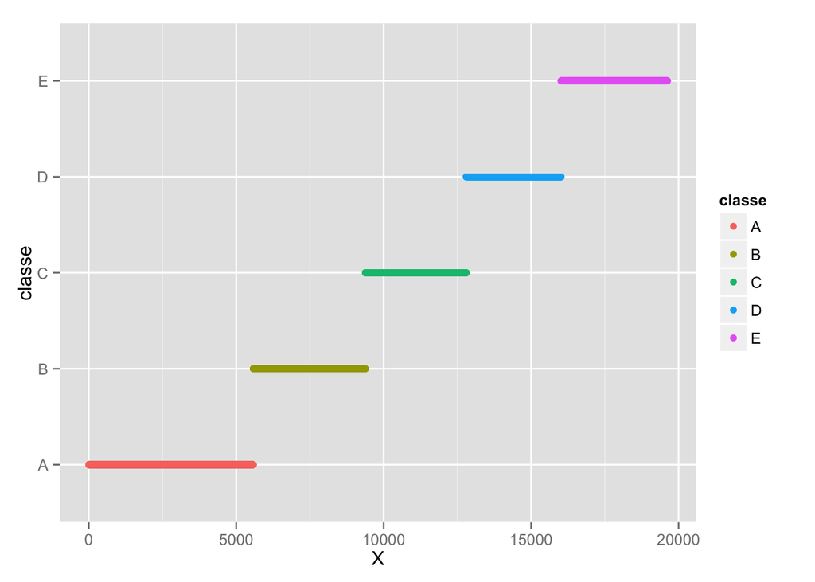

We are left with 52 potential predictors.

```
## [1] "pml_data with 53 columns and 19622 rows"
```

```
## [1] "pml_validation with 53 columns and 20 rows"
```

**Parition data into training and test sets**

We then partition first dataset into training and testing. We’ve initially considered a 60/40 split, but a smaller training set allows for considerably faster model building.

```
## [1] "Using 10.00 percent of data for training"
```

```
## [1] "training with 53 columns and 1964 rows"
```

```
## [1] "testing with 53 columns and 17658 rows"
```

**Decision Trees**

Decision trees (either with or without preprocessing) do not seem to work well for this dataset.

**Random Forest**

We’ve got good results with Random Forests. Training set accuracy is 100% with 95% CI : (0.9981, 1)

```
##
## pred_training   A   B   C   D   E
##             A 558   0   0   0   0
##             B   0 380   0   0   0
##             C   0   0 343   0   0
##             D   0   0   0 322   0
##             E   0   0   0   0 361
```

```
##
## pred_test    A    B    C    D    E
##         A 4852  162    0   16    2
##         B   47 3103  129    2   19
##         C   73  123 2903  127   28
##         D   42   20   45 2739   80
##         E    8    9    2   10 3117
```

**Boosting**

```
##
## pred_training   A   B   C   D   E
##             A 557   4   0   0   0
##             B   1 376   0   0   0
##             C   0   0 342   5   1
##             D   0   0   1 315   4
##             E   0   0   0   2 356
```

Test set accuracy is 93.15% with 95% CI : (0.9277, 0.9352)

```
##
## pred_test    A    B    C    D    E
##         A 4837  228    7    4    9
##         B   83 2999  143    5   57
##         C   68  139 2872  157   54
##         D   11   15   42 2706   90
##         E   23   36   15   22 3036
```

**LDA**

We’ve also attempted to use linear discriminant analysis, with not as great results at the other two. Training set accuracy is 72.4% with 95% confidence interval (0.7037, 0.7437)

```
##    pred_training
##       A   B   C   D   E
##   A 483   9  31  33   2
##   B  46 249  47  14  24
##   C  34  28 221  46  14
##   D  21   7  37 245  12
##   E  17  57  32  31 224
```

Test set accuracy is 69.12% with 95% confidence interval (0.6844, 0.6981)

```
##
## pred_test    A    B    C    D    E
##         A 4076  529  355  203  111
##         B  115 2052  204   86  546
##         C  448  514 2040  366  317
##         D  349  130  390 2121  355
##         E   34  192   90  118 1917
```

**Ensemble Classifier**

Both random forest and boosting models have good accuracy, but they do not always agree. For the project submission, we’ve decided to combine results of the three classifiers using majority vote. With models built on 10% training sample, 19 out of 20 predictions were correct. The one incorrect prediction has a correct class predicted by the gbm model.

```
##    rf gbm lda majorityVote
## 1   B   B   C            B
## 2   A   A   A            A
## 3   B   B   B            B
## 4   A   A   C            A
## 5   A   C   C            C
## 6   E   E   E            E
## 7   D   D   D            D
## 8   D   B   D            D
## 9   A   A   A            A
## 10  A   A   A            A
## 11  B   B   D            B
## 12  C   C   A            C
## 13  B   B   E            B
## 14  A   A   A            A
## 15  E   E   B            E
## 16  E   E   C            E
## 17  A   A   A            A
## 18  B   B   B            B
## 19  A   A   B            A
## 20  B   B   B            B
```